# The Array-Backed List

## Agenda

1. The List **Abstract Data Type** (ADT)
2. A List **Data Structure**
3. Our List API
4. Getting started: how to store our data?
5. Built-in `list` as array
6. The `ArrayList` data structure

## 1. The List **Abstract Data Type** (ADT)

An **abstract data type (ADT)** defines a *conceptual model* for how data may be stored and accessed.

A **list ADT** is a data container where:

- values are ordered in a *sequence*
- each value has at most one preceding and one succeeding value
- a given value may appear more than once in a list

Other common ADTs (some of which we'll explore later) include:

- Stacks
- Queues
- Priority Queues
- Maps
- Graphs

## 2. A List **Data Structure**

A **list data structure** is a *concrete implementation* of the list ADT in some programming language, which, in addition to adhering to the basic premises of the ADT, will also typically support operations that:

- access values in the list by their position (index)
- append and insert new values into the list
- remove values from the list

The implementation of any data structure will generally rely on simpler, constituent data types (e.g., "primitive" types offered by the language), the choice of which may affect the runtime complexities of said operations.

## 3. The List API

The operations we'll be building into our list data structures will be based on the [common](https://docs.python.org/3.6/library/stdtypes.html#common-sequence-operations) and [mutable](https://docs.python.org/3.6/library/stdtypes.html#mutable-sequence-types) sequence operations defined by the Python library.

```python
class List:
    ### subscript-based access ###

    def __getitem__(self, idx):
        """Implements `x = self[idx]`"""
        pass

    def __setitem__(self, idx, value):
        """Implements `self[idx] = x`"""
        pass

    def __delitem__(self, idx):
        """Implements `del self[idx]`"""
        pass

    ### stringification ###

    def __repr__(self):
        """Supports inspection"""
        return '[]'

    def __str__(self):
        """Implements `str(self)`"""
        return '[]'

    ### single-element manipulation ###

    def append(self, value):
        pass

    def insert(self, idx, value):
        pass

    def pop(self, idx=-1):
        pass

    def remove(self, value):
        pass

    ### predicates (T/F queries) ###

    def __eq__(self, other):
        """Implements `self == other`"""
        return True

    def __contains__(self, value):
        """Implements `val in self`"""
        return True

    ### queries ###

    def __len__(self):
        """Implements `len(self)`"""
        return len(self.data)

    def min(self):
        pass

    def max(self):
        pass

    def index(self, value, i, j):
        pass

    def count(self, value):
        pass

    ### bulk operations ###

    def __add__(self, other):
        """Implements `self + other_array_list`"""
        return self

    def clear(self):
        pass

    def copy(self):
        pass

    def extend(self, other):
        pass

    ### iteration ###

    def __iter__(self):
        """Supports iteration (via `iter(self)`)"""
        pass
```

## 4. Getting started: how to store our data?

```python
class List:
    def append(self, value):
        self.val = value

    def __getitem__(self, idx):
        """Implements `x = self[idx]`"""
        return self.val

    def __setitem__(self, idx, value):
        """Implements `self[idx] = x`"""
        self.val = value

    def __repr__(self):
        """Supports inspection"""
        return '[ ' + repr(self.val) + ' ]'
```

```python
l = List()
```

```python
l.append(42)
```

```python
l
```

```
[ 42 ]
```

```python
l[0]
```

```
42
```

```python
l[0] = 331
```

```python
l[50]
```

```
331
```

```python
l
```

```
[ 331 ]
```

But to do this propertly we need to store more than just one element. We could use an array, but Python doesn't have one!

## 5. Built-in `list` as array

To use the built-in list as though it were a primitive array, we will constrain ourselves to just the following APIs on a given list `lst`:

1. `lst[i]` for getting and setting values at an *existing, positive* index `i`
2. `len(lst)` to obtain the number of slots
3. `lst.append(None)` to grow the list by *one slot at a time*
4. `del lst[len(lst)-1]` to delete the last slot in a list

All but #3 are clearly O(1) operations (why?).

### Timing `append`

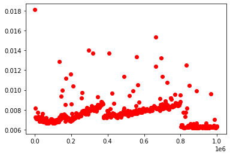

```python
import timeit
import numpy as np
import matplotlib.pyplot as plt

ns = np.linspace(0, 1_000_000, 500, dtype=int)
ts = [timeit.timeit('lst.append(None)',
                    setup=f'lst = list(range({n}))',
                    number=100_000,
                    globals=globals())
      for n in ns]

plt.plot(ns, ts, 'or');
```

Python's built-in list has O(1) runtime complexity for `append`.

It achieves this by *reserving* space for future elements instead of actually growing its backing array by one slot on each call to `append`. When it runs out of space, it allocates a new array with twice the amount of reserved space as the original and copies all existing elements over.

This means that once in a while `append` takes **much longer** than usual. But **on average** -- we call this *amortized analysis* -- this results in O(1) `append`s.

## 6. The `ArrayList` data structure

```python
class ArrayList:
    def __init__(self):
        self.data = [] # "backing store" -- i.e., my data container

    def append(self, value):
        self.data.append(None) # create an empty slot in the backing array
        self.data[len(self.data)-1] = value

    def __getitem__(self, idx):
        """Implements `x = self[idx]`"""
        assert isinstance(idx, int), 'Index must be an integer'

        if idx < 0:
            idx = len(self.data) + idx

        assert idx >=0 and idx < len(self.data)
        return self.data[idx]

    def __setitem__(self, idx, value):
        """Implements `self[idx] = x`"""
        assert isinstance(idx, int)

        if idx < 0:
            idx = len(self.data) + idx

        assert idx >=0 and idx < len(self.data)

        self.data[idx] = value

    def __delitem__(self, idx):
        """Implements `del self[idx]`"""
        assert isinstance(idx, int)

        if idx < 0:
            idx = len(self.data) + idx

        for i in range(idx, len(self.data)-1): # move all elements after idx down one slot
            self.data[i] = self.data[i+1]

        del self.data[len(self.data)-1] # delete the last slot

    def __len__(self):
        """Implements `len(self)`"""
        return len(self.data)

    def __repr__(self):
        """Supports inspection"""
        s = '['
        for i in range(len(self)):
            s += repr(self.data[i]) + ','
        s += ']'
        return s
```

```python
l = ArrayList()
for x in range(10):
    l.append(x)
```

```python
for i in range(len(l)):
    print(l[i])
```

```
0
1
2
3
4
5
6
7
8
9
```

```python
l[5] = 100
l
```

```
[0,1,2,3,4,100,6,7,8,9,]
```

```python
del l[5]
l
```

```
[0,1,2,3,4,6,7,8,9,]
```